# Time course analysis of a Strongyloides stercoralis bulk RNAseq dataset

# Introduction

As an alternative to limma-voom based pairwise differential gene analysis, here we analyze the Stolzfus bulk RNAseq dataset using differential expression alogrithms for longitudinal count data.

### ImpulseDE2

ImpulseDE2 is a method for testing differential expression with longitudinal datasets. In the introductory journal article, the authors point out the distinction between DE algorithms that treat time points independently (e.g. those motly based on linear models, like edgeR, limma, DESeq), and those that explicitly model the dependence between time points. This latter group “constrain the sequence of measured expression levels to a continuous function of time, thus capturing the dependence of expression levels between time points” ( [Fischer, Theis and Yosef, 2018](https://academic.oup.com/nar/article/46/20/e119/5068248) ).  
ImpulseDE2 presents the option of case-only differential expression analysis, that seeks to identify “genes that have non-constant expression trajectories over trim from samples of a single condition.” Mathematically, the impulse algorithm scales the product of two sigmoid functions (thus yielding three state-specific expression values: initial, peak, and steady state). Furthermore, ImpulseDE2 allows users to add additional functionality for determining whether genes are transiently or permanently altered. Thus, an Impulse model can capture 4 different expression trajectories: monotonous decrease, monotonous increase, transient decrease (valley), and transient increase (peak) (see Figure 1A of Fischer, Theis and Yosef (2018) for a schematic of these trajectories). For a tutorial, see this [BioConductor vignette](https://bioconductor.org/packages/release/bioc/vignettes/ImpulseDE2/inst/doc/ImpulseDE2_Tutorial.html).  
For benchmarking of ImpulseDE2 against other options, see [Spies et al 2017](https://academic.oup.com/bib/article/20/1/288/4364840), which found that in general, pairwise differential expression often outperforms longitudinal algorithms in terms of identifying true differentially expressed genes. Nevertheless, they find that ImpulseDE2 does a reasonable job. However, they do recommend controlling for discovery of false positives by using both ImpulseDE2 and another longitudinal method, SplineTC, and taking the intersection of their results. Note that a third option is to capture contintuous dependence on time using a linear models based on a spline basis transform of the time coordinate; this would be accomplished using a linear model based method such as limma or DESeq2 Instructions for running DESeq2 with settings for splines are included in the supplemental materials for [Fischer, Theis and Yosef, 2018](https://academic.oup.com/nar/article/46/20/e119/5068248). However, I don’t think this option would identify transiently altered gene expression, which is the most useful feature of ImpulseDE2.

### Data Pre-Processing

Kallisto and custom R scripts were used to perform ultra-fast read mapping of raw reads to the *S. stercoalis* reference transcriptome (PRJEB528.WBPS14.mRNA_transcripts, downloaded from [WormBase Parasite](https://parasite.wormbase.org/Strongyloides_stercoralis_prjeb528/Info/Index/) on 16 June 2020).

Kallisto alignments are imported into the R environment and annotated with information imported via the Wormbase ParaSite BioMaRT. Annotation information includes: *C. elegans* homologs/percent homology, *S. ratti* homologs/percent homology, UniProtKB number, Interpro terms, GO terms, and general Description information. Annotation information is saved as an R object that is passed to a Shiny Web App for downstream browsing and on-demand analysis.

# Import Kallisto reads into R

This process uses a different project design than the primary data pre-processing script. The ImpulseDE2 design file includes temporal assignments for each sample. Also, not all samples from PRJEB3116 are included: only FLF, iL3, iL3a, and PF are specified. Kallisto reads are imported using different `tximport` parameters - here, abundance values are imported as is whereas the pre-processing script calculates counts from abundance using a `lengthScaledTPM` process that generates estimated counts that are scaled by average transcript length and then library size. In this code, those normalization steps occur in subsequent chunks.

# Gene Annotation

Import gene annotation information for S. stercoralis genes, including: C. elegans homologs/percent homology, S. ratti homologs/percent homology, UniProtKB number, Interpro terms, GO terms, and general Description information using biomart.

# Local copy of plotHeatmap

Include code for local version of plotHeatmap, from the ImpulseDE2 library.

# Run ImpulseDE2

Case-only diffferential expression, without batch effects, with detection of transiently regulated genes. Note that here, the gene counts are rounded to the nearest integer, and the data are neither normalized or filtered for low expression when they are passed into ImpulseDE2 (which will do a normalization step internally, and will remove genes that have no expression at any stage). This code generates a heatmap, which plots genes with differential expression across life stages with a BH-adjusted p-value of less than 0.01. Running ImpulseDE2 on *S. stercoralis* dataset with 4 life stages takes 15-20 minutes on a Macbook Pro.

```r
# ImpulseDE2 Implementation
## Case-only diffferential expression, without batch effects, with transiently regulated genes

## Required inputs: integer count matrix, sample meta data table

# Set up the design matrix ----
sampleTable <- data.frame(group = factor(dfAnnotation$TimeCateg))
rownames(sampleTable) <- dfAnnotation$Sample

# generate DESeqDataSet for use with DESeq2----
dds <- DESeqDataSetFromTximport(Txi_gene_DE, sampleTable, ~0 + group)

# generate count data, note that this is neither normalized or filtered
matCountData <- counts(dds)

objectImpulseDE2 <- runImpulseDE2(
  matCountData = matCountData,
  dfAnnotation = dfAnnotation,
  boolCaseCtrl = FALSE,
  boolIdentifyTransients = TRUE
)
```

```
## Processing Details:
## ImpulseDE2 runs in case-only mode.
## Found time points: 0,1,2,3
## Case: Found the samples at time point 0: ERR146941,ERR146942,ERR146943
## Case: Found the samples at time point 1: ERR146947,ERR146948,ERR146949
## Case: Found the samples at time point 2: ERR146944,ERR146945,ERR146946
## Case: Found the samples at time point 3: ERR146959,ERR146960,ERR146961
## Input contained 13098 genes/regions.
## WARNING: 47 out of 13098 genes do not have obserserved non-zero counts and are excluded.
## Selected 13051 genes/regions for analysis.
```

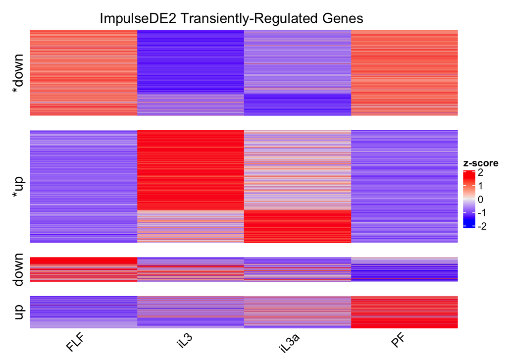

```r
lsHeatmaps <- plotHeatmap_local(
  objectImpulseDE2 = objectImpulseDE2,
  strCondition = "case",
  boolIdentifyTransients = TRUE,
  scaQThres = 0.01,
  col_names = unique(dfAnnotation$TimeCateg))
draw(lsHeatmaps$complexHeatmapRaw,
     column_title = "ImpulseDE2 Transiently-Regulated Genes")
```

# Pull, Annotate, and Collate Trajectory Profiles

Generate annotated lists of genes displaying different trajectory profiles. ImpulseDE2 can identify 4 life-varying expression profiles: transient upregulation, transient downregulation, permanent upregulation, and permanent downregulation.

# Search for Genes of Interest

Here, a proof of concept code chunk that searches the list of trajectory results for a specific subset of genes, the Ss-AFD-rGCs and Ss-tax-4.

### Plot Impulse Fits

Plot the impulse fit for each gene of interest.

```
## [1] "Setting boolSimplePlot=TRUE as no batch structure was found."
```

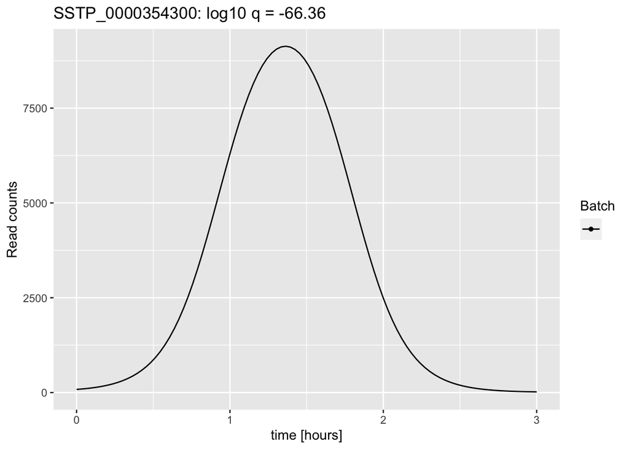

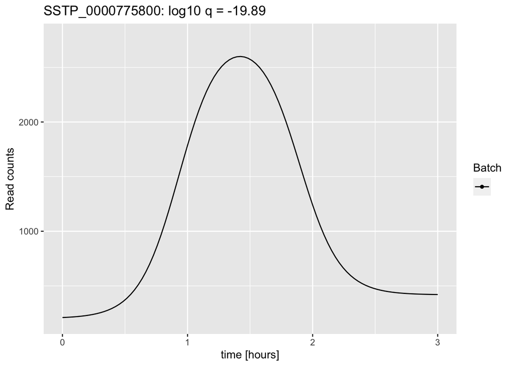

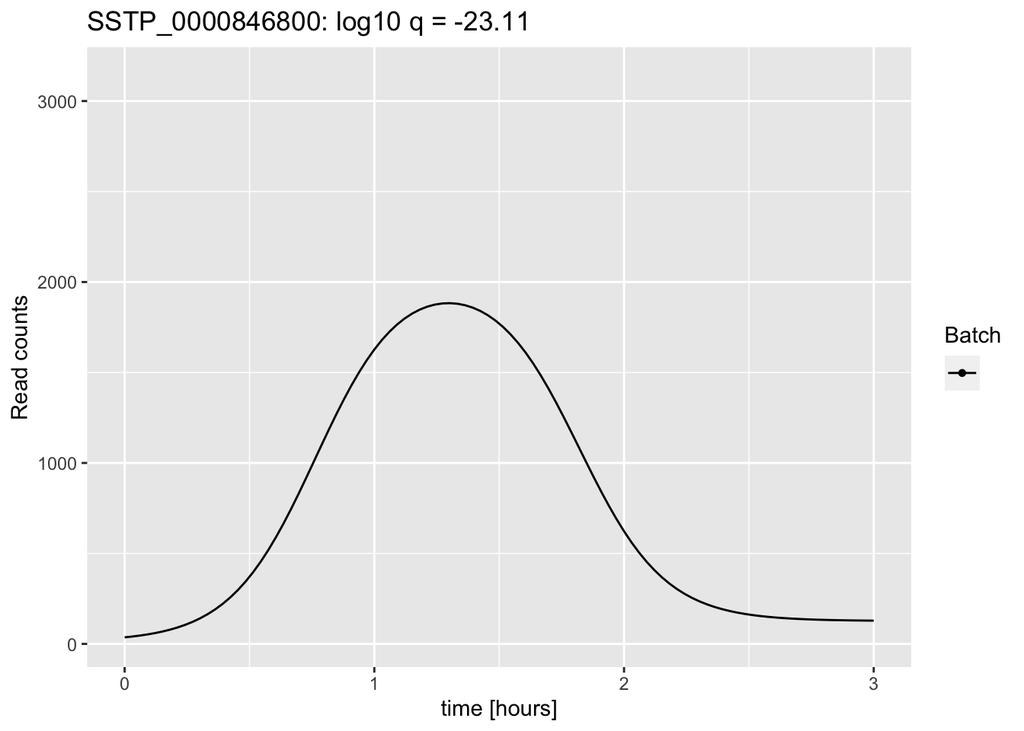

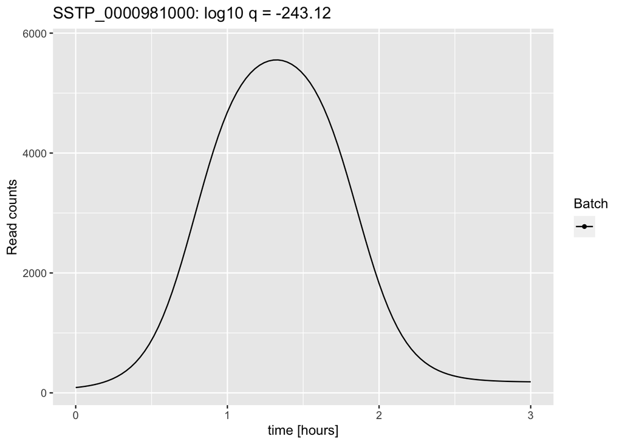

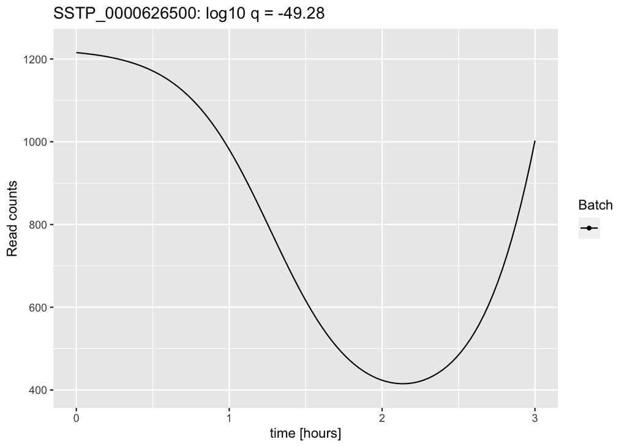

### Generate Annotated Results Table

Print the ImpulseDE2 results table, annotated with gene information from BioMaRT. Table displays average count data for each life stage. Benjamini-Hochberg false-discovery rate corrected p-values are provided for two hypothesis testing schemes used to identify transient gene expression trajectories:  
1. `impulseT0sigmoid_padj` = loglikelihood ratio test of impulse model fit versus sigmoid model on samples  
2. `sigmoidToconst_padj` = loglikelihood test of sigmoidal model fit versus contstant model on samples  
From [Fischer, Theis and Yosef (2018)](https://academic.oup.com/nar/article/46/20/e119/5068248), the way this works is that ImpulseDE2 “compares the fit of a monotonous sigmoid model (i.e. maintained modulation of expression) to an impulse model and a constant model”. Transiently regulated genes are defined as “genes that are significantly better fit by an impulse model than by a sigmoid model and which do not have a monotonous impulse model fit”. Permanently regulated genes are definted as “genes that are not transient but that are significantly better fit by a sigmoid than by a constant model”.  
The effect of these test results on the catergorization of a specific gene is reported by the boolean columns `isTransient` and `isMonotonous`. The table is grouped by the transient identity assginment for each gene (i.e. transiently downregulated genes are printed together, monotonously upregulated genes are printed together).

**Results of ImpulseDE2 analysis for transient gene expression**

for a user-selected gene list

| geneID | FLF | iL3 | iL3a | PF | sigmoidTOconst_padj | impulseTOsigmoid_padj | isTransient | isMonotonous | Str_geneID | Str_WBgeneID | Str_percent_homology | Ce_geneID | Ce_percent_homology | Description | UniProtKB |
| --- | --- | --- | --- | --- | --- | --- | --- | --- | --- | --- | --- | --- | --- | --- | --- |
| transient_up |  |  |  |  |  |  |  |  |  |  |  |  |  |  |  |
| SSTP_0000354300 | 111.67 | 4,528.67 | 3,829.67 | 14.67 | 8.60 × 10<sup>−25</sup> | 1.22 × 10<sup>−44</sup> | TRUE | FALSE | SRAE_2000430600 | WBGene00264536 | 87.9201 | gcy-23 | 58.8071 | Guanylate cyclase | A0A0K0E223 |
| SSTP_0000775800 | 283.33 | 1,480.00 | 1,910.33 | 328.33 | 1.32 × 10<sup>−13</sup> | 5.01 × 10<sup>−9</sup> | TRUE | FALSE | SRAE_0000007100 | WBGene00255808 | 83.1411 | gcy-23 | 56.2908 | Guanylate cyclase | A0A0K0EE46 |
| SSTP_0000846800 | 49.00 | 1,104.33 | 959.67 | 97.67 | 4.60 × 10<sup>−15</sup> | 7.81 × 10<sup>−11</sup> | TRUE | FALSE | SRAE_X000209000 | WBGene00267668 | 71.4924 | gcy-23 | 51.6309 | Guanylate cyclase | A0A0K0EG58 |
| SSTP_0000981000 | 119.67 | 3,549.00 | 2,807.33 | 145.67 | 1.94 × 10<sup>−128</sup> | 1.49 × 10<sup>−117</sup> | TRUE | FALSE | SRAE_2000234000 | WBGene00262550 | 85.6609 | tax-4 | 53.4789 | NA | A0A0K0EK20 |
| transient_down |  |  |  |  |  |  |  |  |  |  |  |  |  |  |  |
| SSTP_0000626500 | 1,637.67 | 758.33 | 649.67 | 782.67 | 4.54 × 10<sup>−21</sup> | 3.30 × 10<sup>−31</sup> | TRUE | FALSE | SRAE_1000291000 | WBGene00259527 | 88.4615 | tax-2 | 46.1250 | NA | A0A0K0E9T3 |

Reference: Soltzfus *et al*, 2012. DOI: 10.1371/journal.pone.0038587

### Generate Annotated Heatmap

Create and annotated heatmap (using `ComplexHeatmap` library) that shows the expression of the gene set.

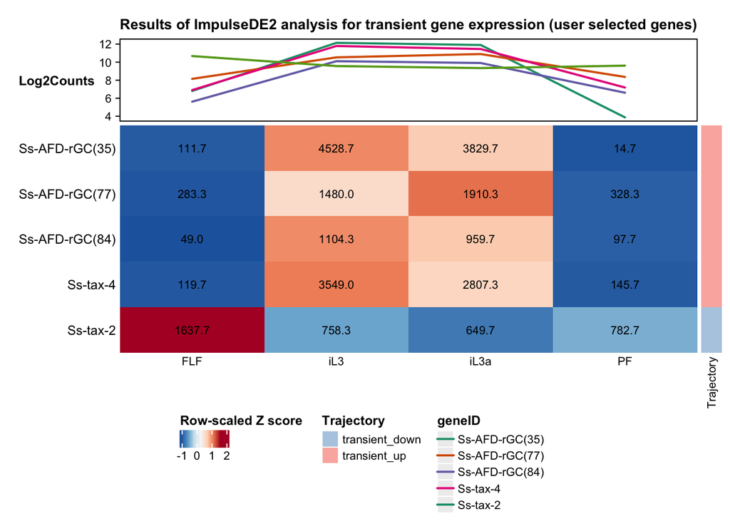

# Appendix: All code for this report

```r
# load packages ----
suppressPackageStartupMessages({
  library(tidyverse)
  library(tximport)
  library(ImpulseDE2)
  library(magrittr)
  library(ggplot2)
  library(DESeq2)
  library(ensembldb)
  library(biomaRt)
  library(ComplexHeatmap)
  library(compiler)
  #source("./Pre_processing/plotHeatmap_local.R")
})
# read in the ImpulseDE2 design ----
dfAnnotation <- read_tsv("../Data/S_stercoralis/Study_Design/PRJEB3116_ImpulseDE2_design.txt",
                         col_types = "ccncc",
                         na = c("", "NA", "na"))

# get annotations using organism-specific package ----
Tx.Ss <- getBM(attributes=c('wbps_transcript_id',
                            'wbps_gene_id'),
               # grab the ensembl annotations for Wormbase Parasite genes
               mart = useMart(biomart="parasite_mart",
                              dataset = "wbps_gene",
                              host="https://parasite.wormbase.org",
                              port = 443),
               filters = c('species_id_1010'),
               value = list('ststerprjeb528')) %>%
  as_tibble() %>%
  #we need to rename the columns retreived from biomart
  dplyr::rename(target_id = wbps_transcript_id,
                gene_name = wbps_gene_id)



# create file paths to the abundance files generated by Kallisto using the 'file.path' function
path <- file.path("../Data/S_stercoralis/Reads",dfAnnotation$Sample, "abundance.tsv")

# import Kallisto transcript counts into R using Tximport ----
# copy the abundance files to the working directory and rename so that each sample has a unique name
Txi_gene_DE <- tximport(path,
                        type = "kallisto",
                        tx2gene = Tx.Ss[,1:2],
                        txOut = FALSE, #How does the result change if this =FALSE vs =TRUE?
                        ignoreTxVersion = FALSE)
# Introduction to this chunk -----------
# This chunk imports gene annotation information for S. stercoralis genes, including:
# C. elegans homologs/percent homology, S. ratti homologs/percent homology, UniProtKB number, Interpro terms, GO terms, and general Description information using biomart.

# Load packages ------
library(biomaRt) # annotate genes using bioMart
#library(biomartr) # extending biomart annotation language


# Get C. elegans homologs for S. stercoralis genes from BioMart and filter -----
Annt.import <- getBM(attributes=c('wbps_gene_id',
                                  'strattprjeb125_gene',
                                  'strattprjeb125_gene_name',
                                  'strattprjeb125_homolog_perc_id_r1',
                                  'caelegprjna13758_gene_name',
                                  'caelegprjna13758_homolog_perc_id_r1',
                                  'description',
                                  'interpro_short_description',
                                  'go_name_1006',
                                  'uniprot_sptrembl'),
                     # grab the ensembl annotations for Wormbase Parasite genes
                     mart = useMart(biomart="parasite_mart",
                                    dataset = "wbps_gene",
                                    host="https://parasite.wormbase.org",
                                    port = 443),
                     filters = c('species_id_1010'),
                     value = list('ststerprjeb528')) %>%
  as_tibble() %>%
  # rename columns
  dplyr::rename(geneID = wbps_gene_id,
                Str_WBgeneID = strattprjeb125_gene,
                Str_geneID = strattprjeb125_gene_name,
                Str_percent_homology = strattprjeb125_homolog_perc_id_r1,
                Ce_geneID = caelegprjna13758_gene_name,
                Ce_percent_homology = caelegprjna13758_homolog_perc_id_r1,
                Description = description,
                GO_term = go_name_1006,
                UniProtKB = uniprot_sptrembl
  ) %>%
  dplyr::group_by(geneID)

# Replace empty string values (mostly in Ce_geneID column) with NAs
Annt.import[Annt.import == ""]<-NA

# Remove any duplications in the possible C. elegans or S. ratti gene homolog matches. Select based on highest % homology.
Annt.import$Ce_percent_homology[is.na(Annt.import$Ce_percent_homology)] <- 1000 #Give fake value here to make sure genes without a Ce homolog aren't filtered out
Annt.import$Str_percent_homology[is.na(Annt.import$Str_percent_homology)] <- 1000


Annt.logs <-Annt.import %>%
  dplyr::select(!c(interpro_short_description:GO_term))%>%
  group_by(geneID) %>%
  slice_max(n = 1, order_by = Ce_percent_homology, with_ties = FALSE) %>%
  slice_max(n = 1, order_by = Str_percent_homology, with_ties = FALSE) %>%
  group_by(geneID, Ce_geneID)

# Remove source code to shorten the description
Annt.logs$Description<- Annt.logs$Description %>%
  str_replace_all(string = ., pattern = "  \\[Source:.*\\]", replacement = "") %>%
  cbind()

Annt.logs$Ce_percent_homology[Annt.logs$Ce_percent_homology == 1000] <- NA
Annt.logs$Str_percent_homology[Annt.logs$Str_percent_homology == 1000]<- NA

# Clean up interprotKB terms, removing duplications and collapsing to one line
Annt.interpro<-Annt.import %>%
  dplyr::select(geneID, Ce_geneID, interpro_short_description) %>%
  group_by(geneID, Ce_geneID) %>%
  dplyr::distinct(interpro_short_description, .keep_all = TRUE) %>%
  dplyr::summarise(InterPro = paste(interpro_short_description,
                                    collapse = ', '))
# Clean up GO terms, removing duplications and collapsing to one line
Annt.goterms<-Annt.import %>%
  dplyr::select(geneID, Ce_geneID, GO_term) %>%
  group_by(geneID, Ce_geneID) %>%
  dplyr::distinct(GO_term, .keep_all = TRUE) %>%
  dplyr::summarise(GO_term = paste(GO_term, collapse = ', '))

annotations<-dplyr::left_join(Annt.logs, Annt.interpro) %>%
  dplyr::left_join(.,Annt.goterms) %>%
  ungroup() %>%
  dplyr::relocate(Str_geneID, Str_WBgeneID,Str_percent_homology, .after = geneID) %>%
  column_to_rownames(var = "geneID")

suppressPackageStartupMessages({
  library(compiler)
})
### Plot z-value heatmaps
```

```r
#' Plot structured z-value heatmaps of differentially expressed genes
#'
#' Creates a complexHeatmap heatmap structured into
#' subsets of genes according to their behaviour and
#' sorted by peak time for raw counts and for the
#' fitted signal.
#'
#' @seealso Called seperately by used.
#'
#' @param objectImpulseDE2 (instance of class ImpulseDE2Object)
#' ImpulseDE2 output object to create heatmap from.
#' @param strCondition (str) {'case','control','combined}
#' Heatmap is created from samples of this condition.
#' @param boolIdentifyTransients (bool)
#' Whether to structure heatmap into transient and transition
#' trajectories, only possible if sigmoids were fit to the
#' indicated condition.
#' @param scaQThres (scalar) FDR-corrected p-value threshold
#' for calling differentially expressed genes: Only genes
#' below this threshold are included in the heatmap.
#'
#' @return (list length 3)
#' \itemize{
#' \item complexHeatmapRaw (complexHeatmap plot)
#' Heatmap of raw data by time point: Average of the
#' size factor (and batch factor) normalised counts
#' per time point and gene.
#' Plot with draw(complexHeatmapRaw).
#' \item complexHeatmapFit (complexHeatmap plot)
#' Heatmap of impulse-fitted data by time point.
#' Plot with draw(complexHeatmapFit).
#' \item lsvecGeneGroups (list)
#' List of gene ID vectors: One per heatmap group
#' with all gene IDs of the the profiles displayed
#' in the heatmap.
#' }
#'
#' @examples
#' library(ComplexHeatmap)
#' lsSimulatedData <- simulateDataSetImpulseDE2(
#' vecTimePointsA   = rep(seq(1,8),3),
#' vecTimePointsB   = NULL,
#' vecBatchesA      = NULL,
#' vecBatchesB      = NULL,
#' scaNConst        = 0,
#' scaNImp          = 50,
#' scaNLin          = 0,
#' scaNSig          = 50)
#' objectImpulseDE2 <- runImpulseDE2(
#' matCountData    = lsSimulatedData$matObservedCounts,
#' dfAnnotation    = lsSimulatedData$dfAnnotation,
#' boolCaseCtrl    = FALSE,
#' vecConfounders  = NULL,
#' boolIdentifyTransients = TRUE,
#' scaNProc        = 1 )
#' lsHeatmaps <- plotHeatmap(
#' objectImpulseDE2=objectImpulseDE2,
#' strCondition='case',
#' boolIdentifyTransients=TRUE,
#' scaQThres=0.01)
#' draw(lsHeatmaps$complexHeatmapRaw)
#'
#' @author David Sebastian Fischer
#' @author Astra Shamgar Bryant (editing local copy)
#'
#' @import ComplexHeatmap
#' @import circlize
#'
#' @export
#'
plotHeatmap_local <- function(
  objectImpulseDE2, strCondition, boolIdentifyTransients,
  scaQThres = 0.01, col_names) {

  dfAnnot <- get_dfAnnotationProc(obj=objectImpulseDE2)

  scaNGenes <- dim(get_matCountDataProc(obj=objectImpulseDE2))[1]
  # Order genes by time of extremum (peak/valley)
  vecSignificantIDs <- rownames(objectImpulseDE2$dfImpulseDE2Results[
    !is.na(objectImpulseDE2$dfImpulseDE2Results$padj) &
      objectImpulseDE2$dfImpulseDE2Results$padj < scaQThres, ])
  vecTimePointsToEval <- sort(unique(dfAnnot$Time),
                              decreasing = FALSE)
  scaNTPtoEvaluate <- length(vecTimePointsToEval)
  matImpulseValue <- do.call(rbind, lapply(
    vecSignificantIDs, function(x) {
      evalImpulse_comp(
        vecImpulseParam =
          get_lsModelFits(obj=objectImpulseDE2)[[strCondition]][[x]]$
          lsImpulseFit$vecImpulseParam,
        vecTimepoints = vecTimePointsToEval)
    }))
  rownames(matImpulseValue) <- vecSignificantIDs
  matidxMaxTimeSort <- t(apply(matImpulseValue, 1, function(genevalues) {
    sort(genevalues, decreasing = TRUE, index.return = TRUE)$ix
  }))
  vecMaxTime <- vecTimePointsToEval[matidxMaxTimeSort[, 1]]
  matidxMinTimeSort <- t(apply(matImpulseValue, 1, function(genevalues) {
    sort(genevalues, decreasing = FALSE, index.return = TRUE)$ix
  }))

  if (boolIdentifyTransients) {
    # Group into transients and monotonous
    vecidxTransient <- which(objectImpulseDE2$dfImpulseDE2Results[vecSignificantIDs,
                                                                  ]$isTransient)
    vecidxMonotonous <- which(objectImpulseDE2$dfImpulseDE2Results[vecSignificantIDs,
                                                                   ]$isMonotonous)

    # Fine sort montonous transition signals into up/down
    if (length(vecidxMonotonous) == 1) {
      matImpulseMonot <- t(matImpulseValue[vecidxMonotonous, ])
    } else {
      matImpulseMonot <- matImpulseValue[vecidxMonotonous, ]
    }
    vecboolMonotonousUp <- apply(matImpulseMonot, 1, function(gene) {
      gene[1] < gene[scaNTPtoEvaluate]
    })
    vecboolMonotonousDown <- !vecboolMonotonousUp

    vecidxMonotonousUp <- vecidxMonotonous[vecboolMonotonousUp]
    vecidxMonotonousUpSort <- vecidxMonotonousUp[
      do.call(order, as.data.frame(
        matidxMinTimeSort[vecidxMonotonousUp,1]))]
    vecidxMonotonousDown <- vecidxMonotonous[vecboolMonotonousDown]
    vecidxMonotonousDownSort <- vecidxMonotonousDown[
      do.call(order, as.data.frame(
        matidxMinTimeSort[vecidxMonotonousDown, 1]))]

    # Fine sort transitive signals into off/on
    if (length(vecidxTransient) == 1) {
      matImpulseTransient <- t(matImpulseValue[vecidxTransient, ])
    } else {
      matImpulseTransient <- matImpulseValue[vecidxTransient, ]
    }
    vecboolTransientValley <- apply(
      matImpulseTransient, 1, function(genevalues) {
        boolValley <- any(
          genevalues[2:(scaNTPtoEvaluate - 1)] < genevalues[1] &
            genevalues[2:(scaNTPtoEvaluate - 1)] <
            genevalues[scaNTPtoEvaluate])
        return(boolValley)
      })
    vecboolTransientPeak <- !vecboolTransientValley

    vecidxTransientPeak <- vecidxTransient[vecboolTransientPeak]
    vecidxTransientPeakSort <- vecidxTransientPeak[
      do.call(order, as.data.frame(
        matidxMaxTimeSort[vecidxTransientPeak, 1]))]
    vecidxTransientValley <- vecidxTransient[vecboolTransientValley]
    vecidxTransientValleySort <- vecidxTransientValley[
      do.call(order, as.data.frame(
        matidxMinTimeSort[vecidxTransientValley,1]))]

    vecidxAllSort <- c(
      vecidxMonotonousUpSort, vecidxMonotonousDownSort,
      vecidxTransientPeakSort, vecidxTransientValleySort)
```

```r
    vecTrajectoryType <- c(
      rep("up", length(vecidxMonotonousUpSort)),
      rep("down", length(vecidxMonotonousDownSort)),
      rep("*up", length(vecidxTransientPeakSort)),
      rep("*down", length(vecidxTransientValleySort)))
    lsvecGeneGroups <- list(
      transition_up = vecSignificantIDs[vecidxMonotonousUpSort],
      transition_down =  vecSignificantIDs[vecidxMonotonousDownSort],
      transient_up = vecSignificantIDs[vecidxTransientPeakSort],
      transient_down = vecSignificantIDs[vecidxTransientValleySort])
  } else {
    vecidxAllSort <- sort(vecMaxTime, decreasing = FALSE,
                          index.return = TRUE)$ix
    vecTrajectoryType <- rep(" ", length(vecidxAllSort))
    lsvecGeneGroups <- list(all = vecSignificantIDs[vecidxAllSort])
  }

  vecUniqueTP <- unique(dfAnnot$Time)
  vecSizeFactors <- computeNormConst(
    matCountDataProc = get_matCountDataProc(obj=objectImpulseDE2),
    vecSizeFactorsExternal = get_vecSizeFactors(obj=objectImpulseDE2))
  matSizefactors <- matrix(
    vecSizeFactors, nrow = length(vecSignificantIDs),
    ncol = dim(get_matCountDataProc(obj=objectImpulseDE2))[2], byrow = TRUE)

  # 1. Plot raw data
  matDataNorm <- get_matCountDataProc(obj=objectImpulseDE2)[vecSignificantIDs, ]/matSizefactors
  matDataHeat <- do.call(cbind, lapply(vecUniqueTP, function(tp) {
    vecidxCols <- which(dfAnnot$Time %in% tp)
    if (length(vecidxCols) > 1) {
      return(rowMeans(matDataNorm[, vecidxCols], na.rm = TRUE))
    } else {
      return(matDataNorm[, vecidxCols])
    }
  }))

  colnames(matDataHeat) <- vecUniqueTP
  rownames(matDataHeat) <- NULL
  # Row normalisation: z-scores
  matDataHeatZ <- do.call(rbind, lapply(
    seq(1, dim(matDataHeat)[1]), function(i) {
      (matDataHeat[i, ] - mean(matDataHeat[i, ], na.rm = TRUE))/
        sd(matDataHeat[i,], na.rm = TRUE)
    }))

  # Create heatmap of raw data, ordered by fits
  complexHeatmapRaw <- Heatmap(
    matDataHeatZ[vecidxAllSort, ],
    gap = unit(5, "mm"), split = vecTrajectoryType,
    cluster_rows = FALSE, cluster_columns = FALSE,
    column_labels = col_names,
    column_names_rot = 45,
    heatmap_legend_param = list(title = "z-score"))

  # 2. Plot fitted data
  matDataHeat <- matImpulseValue
  colnames(matDataHeat) <- vecUniqueTP
  rownames(matDataHeat) <- NULL
  # Row normalisation: z-scores
  matDataHeatZ <- do.call(rbind, lapply(
    seq(1, dim(matDataHeat)[1]), function(i) {
      (matDataHeat[i, ] - mean(matDataHeat[i, ], na.rm = TRUE))/
        sd(matDataHeat[i,], na.rm = TRUE)
    }))

  # Create heatmap of raw data, ordered by fits
  complexHeatmapFit <- Heatmap(
    matDataHeatZ[vecidxAllSort, ],
    gap = unit(5, "mm"), split = vecTrajectoryType,
    cluster_rows = FALSE, cluster_columns = FALSE,
    column_labels = col_names,
    column_names_rot = 45,
    heatmap_legend_param = list(title = "z-score"))

  return(list(complexHeatmapRaw = complexHeatmapRaw,
              complexHeatmapFit = complexHeatmapFit,
              lsvecGeneGroups = lsvecGeneGroups))
}

### Compute value of impulse model

#' Compute value of impulse function given parameters.
#'
#' Compute value of impulse function given parameters.
#' Enforces lower bound on value of function to avoid numerical
#' errors during model fitting.
#'
#' @seealso Compiled version: \link{evalImpulse_comp}
#'
#' @param vecImpulseParam (numeric vector number of impulse model parameters)
#' \{beta, h0, h1, h2, t1, t2\}
#' Vector of impulse model parameters.
#' @param vecTimepoints (numeric vector length number of time points)
#' Time points to be evaluated.
#'
#' @return vecImpulseValue (vec number of vecTimepoints)
#' Model values for given time points.
#'
#' @author David Sebastian Fischer
evalImpulse <- function(vecImpulseParam, vecTimepoints) {

  # beta is vecImpulseParam[1] h0 is vecImpulseParam[2] h1 is
  # vecImpulseParam[3] h2 is vecImpulseParam[4] t1 is vecImpulseParam[5]
  # t2 is vecImpulseParam[6]

  vecImpulseValue <- sapply(vecTimepoints, function(t) {
    (1/vecImpulseParam[3]) *
      (vecImpulseParam[2] + (vecImpulseParam[3] - vecImpulseParam[2]) *
         (1/(1 + exp(-vecImpulseParam[1] * (t - vecImpulseParam[5]))))) *
      (vecImpulseParam[4] + (vecImpulseParam[3] - vecImpulseParam[4]) *
         (1/(1 + exp(vecImpulseParam[1] * (t - vecImpulseParam[6])))))
  })
  vecImpulseValue[vecImpulseValue < 10^(-10)] <- 10^(-10)

  return(vecImpulseValue)
}

#' Compiled function: evalImpulse
#'
#' Pre-compile heavily used functions.
#' Refer to \link{evalImpulse}.
#'
#' @param vecImpulseParam (numeric vector number of impulse model parameters)
#' \{beta, h0, h1, h2, t1, t2\}
#' Vector of impulse model parameters.
#' @param vecTimepoints (numeric vector length number of time points)
#' Time points to be evaluated.
#'
#' @return vecImpulseValue (vec number of vecTimepoints)
#' Model values for given time points.
#'
#' @author David Sebastian Fischer
evalImpulse_comp <- cmpfun(evalImpulse)
# ImpulseDE2 Implementation
## Case-only diffferential expression, without batch effects, with transiently regulated genes

## Required inputs: integer count matrix, sample meta data table

# Set up the design matrix ----
sampleTable <- data.frame(group = factor(dfAnnotation$TimeCateg))
rownames(sampleTable) <- dfAnnotation$Sample

# generate DESeqDataSet for use with DESeq2----
dds <- DESeqDataSetFromTximport(Txi_gene_DE, sampleTable, ~0 + group)

# generate count data, note that this is neither normalized or filtered
matCountData <- counts(dds)

objectImpulseDE2 <- runImpulseDE2(
  matCountData = matCountData,
  dfAnnotation = dfAnnotation,
  boolCaseCtrl = FALSE,
  boolIdentifyTransients = TRUE
)

lsHeatmaps <- plotHeatmap_local(
  objectImpulseDE2 = objectImpulseDE2,
  strCondition = "case",
  boolIdentifyTransients = TRUE,
  scaQThres = 0.01,
  col_names = unique(dfAnnotation$TimeCateg))
draw(lsHeatmaps$complexHeatmapRaw,
     column_title = "ImpulseDE2 Transiently-Regulated Genes")
suppressPackageStartupMessages({
  library(limma)
  library(gt)
  library(htmlwidgets)
})
```

```r
colnames(matCountData) <- dfAnnotation$TimeCateg
matCountData.avg <- avearrays(matCountData) %>%
  as_tibble(rownames = "geneID")
ImpulseDE2.results = objectImpulseDE2$dfImpulseDE2Results %>%
  as_tibble(rownames = 'geneID')

# Subset gene counts and annotations depending on trajectory assignment
trajectory.results.list <- lapply(lsHeatmaps$lsvecGeneGroups, function(x) {
  annotations[x,] %>%
    as_tibble(rownames = 'geneID')%>%
    right_join(dplyr::select(ImpulseDE2.results,
                             geneID, sigmoidTOconst_padj,
                             impulseTOsigmoid_padj, isTransient,
                             isMonotonous),
               ., by = "geneID") %>%
    right_join(matCountData.avg, ., by = "geneID")
})

trajectory.results.df <- trajectory.results.list %>% bind_rows(.id = "class") %>% group_by(class)

suppressPackageStartupMessages({
  library(pheatmap)
  library(RColorBrewer)
  library(ComplexHeatmap)
  library(circlize)
})

# Genes of Interest ----
genes_of_interest <- c('SSTP_0000354300','SSTP_0000775800','SSTP_0000846800','SSTP_0000981000','SSTP_0000626500')

# Plot the impulse fit for each gene of interest ----
suppressWarnings({
plotGenes(
  vecGeneIDs       = genes_of_interest,
  scaNTopIDs       = NULL,
  objectImpulseDE2 = objectImpulseDE2,
  boolCaseCtrl     = FALSE,
  dirOut           = NULL,
  strFileName      = NULL,
  boolMultiplePlotsPerPage = TRUE,
  boolSimplePlot=TRUE)
})
goi.trajectory.results.df <- trajectory.results.df %>%
  dplyr::filter(geneID %in% genes_of_interest)

# Make a table for the genes of interest ----
goi.trajectory.results.df[,1:17] %>%
  gt(rowname_col = "geneID") %>%
  tab_stubhead(label = "geneID") %>%
  tab_header (title = md("**Results of ImpulseDE2 analysis for transient gene expression**"),
              subtitle = md("for a user-selected gene list")) %>%
  opt_align_table_header(align = "left") %>%
  opt_table_outline() %>%
  opt_row_striping() %>%
  tab_source_note(
    source_note = md("Reference: Soltzfus *et al*, 2012. DOI: 10.1371/journal.pone.0038587")
  ) %>%
  fmt_number(
    columns = c(3:6),
    decimals = 2
  )%>%
  fmt_scientific(
    columns = c(7:8),
    decimals = 2
  )
goi.geneIDs <- c('Ss-AFD-rGC(35)','Ss-AFD-rGC(77)','Ss-AFD-rGC(84)','Ss-tax-4','Ss-tax-2')
# Make a heatmap for the genes of interest using the average count values
goi.matrix <- goi.trajectory.results.df[,3:6] %>%
  as.matrix()
rownames(goi.matrix) <- goi.trajectory.results.df$geneID
rownames(goi.matrix) <- goi.geneIDs
colnames(goi.matrix) <- unique(dfAnnotation$TimeCateg)

goi.annotations <- goi.trajectory.results.df %>% ungroup()%>%
  dplyr::mutate(Trajectory = as.factor(class)) %>%
  dplyr::select(Trajectory) %>%
  as.data.frame()
rownames(goi.annotations) <- goi.trajectory.results.df$geneID
rownames(goi.annotations) <- goi.geneIDs

palette(brewer.pal(7,name = "Dark2"))
col_ha <-HeatmapAnnotation(Log2Counts = anno_lines(log2(t(goi.matrix)),
                                                   gp = gpar(col = 1:nrow(goi.matrix),
                                                             lwd = 2)),
                           annotation_name_side = "left",
                           annotation_name_rot = 0,
                           annotation_name_gp = gpar(fontsize = 9, fontface = "bold"),
                           annotation_height = unit(20, "mm"))

class.col <- (brewer.pal(4,"Pastel1"))
row_ha <- rowAnnotation(Trajectory = goi.annotations$Trajectory,
                        col = list(Trajectory = c('transient_down' = class.col[2],
                                                  'transient_up' = class.col[1],
                                                  'transition_down' = class.col[3],
                                                  'transition_up' = class.col[4])),
                        annotation_name_gp = gpar(fontsize = 8),
                        annotation_legend_param = list(
                          Trajectory = list(
                            labels_gp = gpar(fontsize = 8),
                            title_gp = gpar(fontsize = 9, fontface = "bold")
                          )
                        ))

lgd_list <- list(
  Legend(labels = rownames(goi.matrix), title = "geneID", type = "lines",
         labels_gp = gpar(fontsize = 8),
         title_gp = gpar(fontsize = 9, fontface = "bold"),
         legend_gp = gpar(col = 1:ncol(goi.matrix),
                          lwd = 2)))

goi.matrix.scaled <- t(scale(t(goi.matrix)))
#col_fun <- colorRamp2(c(-2, -1, -0.5, 0, 0.5, 1, 2), rev(brewer.pal(7,"RdBu")))
ht_list <- Heatmap(goi.matrix.scaled,
                   name = 'Row-scaled Z score',
                   col = rev(brewer.pal(7,"RdBu")),
                   column_title = "Results of ImpulseDE2 analysis for transient gene expression (user selected genes)",
                   column_title_gp = gpar(fontsize = 10, fontface = "bold"),
                   row_names_gp = gpar(fontsize = 9),
                   cluster_rows = F,
                   cluster_columns = F,
                   row_names_side = "left",
                   column_names_rot = 0,
                   column_names_centered = T,
                   column_names_gp = gpar(fontsize = 8),
                   right_annotation = row_ha,
                   top_annotation = col_ha,
                   layer_fun = function(j, i, x, y, width, height, fill) {
                     # since grid.text can also be vectorized
                     grid.text(sprintf("%.1f", pindex(goi.matrix, i, j)), x, y, gp = gpar(fontsize = 8))
                   },
                   heatmap_legend_param = list(
                     direction = "horizontal",
                     labels_gp = gpar(fontsize = 8),
                     title_gp = gpar(fontsize = 9,
                                     fontface = "bold")))

draw(ht_list,merge_legend = T, heatmap_legend_side = "bottom", annotation_legend_side = "bottom",annotation_legend_list = lgd_list)
```